# Loan data exploration

## Preliminary Wrangling

> We explore a dataset containing 113,937 loans with 81 variables on each loan, including loan amount, borrower rate (or interest rate), current loan status, borrower income, and many others.

```python
# import all packages and set plots to be embedded inline
import numpy as np
import pandas as pd
import matplotlib.pyplot as plt
import seaborn as sb

%matplotlib inline
```

> Load in your dataset and describe its properties through the questions below. Try and motivate your exploration goals through this section.

```python
df=pd.read_csv('prosperLoanData.csv')
df.head()
```

|  | ListingKey | ListingNumber | ListingCreationDate | CreditGrade | Term | LoanStatus | ClosedDate | BorrowerAPR | BorrowerRate | LenderYield | ... | LP_ServiceFees | LP_CollectionFees | LP_GrossPrincipalLoss | LP_NetPrincipalLoss | LP_NonPrincipalRecoverypayments | PercentFunded | Recommendations | InvestmentFromFriendsCount | InvestmentFromFriendsAmount | Investors |
| --- | --- | --- | --- | --- | --- | --- | --- | --- | --- | --- | --- | --- | --- | --- | --- | --- | --- | --- | --- | --- | --- |
| 0 | 1021339766868145413AB3B | 193129 | 2007-08-26 19:09:29.263000000 | C | 36 | Completed | 2009-08-14 00:00:00 | 0.16516 | 0.1580 | 0.1380 | ... | -133.18 | 0.0 | 0.0 | 0.0 | 0.0 | 1.0 | 0 | 0 | 0.0 | 258 |
| 1 | 10273602499503308B223C1 | 1209647 | 2014-02-27 08:28:07.900000000 | NaN | 36 | Current | NaN | 0.12016 | 0.0920 | 0.0820 | ... | 0.00 | 0.0 | 0.0 | 0.0 | 0.0 | 1.0 | 0 | 0 | 0.0 | 1 |
| 2 | 0EE9337825851032864889A | 81716 | 2007-01-05 15:00:47.090000000 | HR | 36 | Completed | 2009-12-17 00:00:00 | 0.28269 | 0.2750 | 0.2400 | ... | -24.20 | 0.0 | 0.0 | 0.0 | 0.0 | 1.0 | 0 | 0 | 0.0 | 41 |
| 3 | 0EF5356002482715299901A | 658116 | 2012-10-22 11:02:35.010000000 | NaN | 36 | Current | NaN | 0.12528 | 0.0974 | 0.0874 | ... | -108.01 | 0.0 | 0.0 | 0.0 | 0.0 | 1.0 | 0 | 0 | 0.0 | 158 |
| 4 | 0F023589499656230C5E3E2 | 909464 | 2013-09-14 18:38:39.097000000 | NaN | 36 | Current | NaN | 0.24614 | 0.2085 | 0.1985 | ... | -60.27 | 0.0 | 0.0 | 0.0 | 0.0 | 1.0 | 0 | 0 | 0.0 | 20 |

5 rows × 81 columns

```python
df.shape
```

```
(113937, 81)
```

#### The dictionary for the data of interest.

- loanOrginalAmount=the original amount of loan.
- BorrowerAPR=borrower annual percentage of the loan.
- prosperRating=The Prosper Rating assigned at the time the listing was created between AA - HR. Applicable for loans originated after July 2009.
- Term=How many months can the loan expressed
- Stated monthlyincome=el borrower bya5od kam per month
- DebtToIncomeRatio=The debt to income ratio of the borrower at the time the credit profile was pulled. This value is Null if the debt to income ratio is not available. This value is capped at 10.01 (any debt to income ratio larger than 1000% will be returned as 1001%).
- Loan status=The current status of the loan: Cancelled, Chargedoff, Completed, Current, Defaulted, FinalPaymentInProgress, PastDue. The PastDue status will be accompanied by a delinquency bucket.
- Employment status=The employment status of the borrower at the time they posted the listing.

```python
#get the data of interest
cols = ['LoanOriginalAmount', 'BorrowerAPR', 'StatedMonthlyIncome', 'Term', 'ProsperRating (Alpha)', 'DebtToIncomeRatio'
       , 'EmploymentStatus','LoanStatus','MonthlyLoanPayment','ListingCreationDate','IsBorrowerHomeowner']
df = df[cols]
df.info()
```

```
<class 'pandas.core.frame.DataFrame'>
RangeIndex: 113937 entries, 0 to 113936
Data columns (total 11 columns):
 #   Column                 Non-Null Count   Dtype
---  ------                 --------------   -----
 0   LoanOriginalAmount     113937 non-null  int64
 1   BorrowerAPR            113912 non-null  float64
 2   StatedMonthlyIncome    113937 non-null  float64
 3   Term                   113937 non-null  int64
 4   ProsperRating (Alpha)  84853 non-null   object
 5   DebtToIncomeRatio      105383 non-null  float64
 6   EmploymentStatus       111682 non-null  object
 7   LoanStatus             113937 non-null  object
 8   MonthlyLoanPayment     113937 non-null  float64
 9   ListingCreationDate    113937 non-null  object
 10  IsBorrowerHomeowner    113937 non-null  bool
dtypes: bool(1), float64(4), int64(2), object(4)
memory usage: 8.8+ MB
```

```python
df.head()
```

|  | LoanOriginalAmount | BorrowerAPR | StatedMonthlyIncome | Term | ProsperRating (Alpha) | DebtToIncomeRatio | EmploymentStatus | LoanStatus | MonthlyLoanPayment | ListingCreationDate | IsBorrowerHomeowner |
| --- | --- | --- | --- | --- | --- | --- | --- | --- | --- | --- | --- |
| 0 | 9425 | 0.16516 | 3083.333333 | 36 | NaN | 0.17 | Self-employed | Completed | 330.43 | 2007-08-26 19:09:29.263000000 | True |
| 1 | 10000 | 0.12016 | 6125.000000 | 36 | A | 0.18 | Employed | Current | 318.93 | 2014-02-27 08:28:07.900000000 | False |
| 2 | 3001 | 0.28269 | 2083.333333 | 36 | NaN | 0.06 | Not available | Completed | 123.32 | 2007-01-05 15:00:47.090000000 | False |
| 3 | 10000 | 0.12528 | 2875.000000 | 36 | A | 0.15 | Employed | Current | 321.45 | 2012-10-22 11:02:35.010000000 | True |
| 4 | 15000 | 0.24614 | 9583.333333 | 36 | D | 0.26 | Employed | Current | 563.97 | 2013-09-14 18:38:39.097000000 | True |

```python
df.drop_duplicates(inplace=True)
df.shape
```

```
(113066, 11)
```

```python
#drop null rows
df.dropna(inplace=True)
```

```python
df.info()
```

```
<class 'pandas.core.frame.DataFrame'>
Int64Index: 76768 entries, 1 to 113936
Data columns (total 11 columns):
 #   Column                 Non-Null Count  Dtype
---  ------                 --------------  -----
 0   LoanOriginalAmount     76768 non-null  int64
 1   BorrowerAPR            76768 non-null  float64
 2   StatedMonthlyIncome    76768 non-null  float64
 3   Term                   76768 non-null  int64
 4   ProsperRating (Alpha)  76768 non-null  object
 5   DebtToIncomeRatio      76768 non-null  float64
 6   EmploymentStatus       76768 non-null  object
 7   LoanStatus             76768 non-null  object
 8   MonthlyLoanPayment     76768 non-null  float64
 9   ListingCreationDate    76768 non-null  object
 10  IsBorrowerHomeowner    76768 non-null  bool
dtypes: bool(1), float64(4), int64(2), object(4)
memory usage: 6.5+ MB
```

```python
# Splitting ListingCreationDate column into year,month
df['year']=df['ListingCreationDate'].apply(lambda x: x.split("-")[0]).astype(str)
df['month'] = df['ListingCreationDate'].apply(lambda x: x.split("-")[1]).astype(str)
```

```python
df.month.replace(['01','02','03','04','05','06','07','08','09','10','11','12'],['Jan','Feb','Mar','Apr','May','Jun','Jul','Aug','Sept','Oct','Nov','Dec'],inplace = True)
```

```python
df['month'].unique()
```

```
array(['Feb', 'Oct', 'Sept', 'Dec', 'Apr', 'May', 'Jul', 'Aug', 'Nov',
       'Jan', 'Jun', 'Mar'], dtype=object)
```

```python
df['StatedMonthlyIncome'].unique()
```

```
array([ 6125.      ,  2875.      ,  9583.333333, ...,  3430.583333,
        1539.166667, 18756.      ])
```

```python
#Let's see if there is dublicates in this dataset
sum(df.duplicated())
```

```
0
```

```python
df.describe()
```

|  | LoanOriginalAmount | BorrowerAPR | StatedMonthlyIncome | Term | DebtToIncomeRatio | MonthlyLoanPayment |
| --- | --- | --- | --- | --- | --- | --- |
| count | 76768.000000 | 76768.000000 | 76768.000000 | 76768.000000 | 76768.000000 | 76768.000000 |
| mean | 9248.961416 | 0.223978 | 5964.256138 | 42.701230 | 0.258692 | 295.275039 |
| std | 6389.782292 | 0.079291 | 5089.682309 | 11.710835 | 0.319727 | 189.109061 |
| min | 1000.000000 | 0.045830 | 0.250000 | 12.000000 | 0.000000 | 0.000000 |
| 25% | 4000.000000 | 0.162590 | 3528.895834 | 36.000000 | 0.150000 | 158.330000 |
| 50% | 8000.000000 | 0.215660 | 5000.000000 | 36.000000 | 0.220000 | 256.120000 |
| 75% | 14000.000000 | 0.287800 | 7166.666667 | 60.000000 | 0.320000 | 392.010000 |
| max | 35000.000000 | 0.423950 | 483333.333333 | 60.000000 | 10.010000 | 2251.510000 |

```python
df['ProsperRating (Alpha)'].unique()
```

```
array(['A', 'D', 'B', 'E', 'C', 'AA', 'HR'], dtype=object)
```

```python
df['EmploymentStatus'].unique()
```

```
array(['Employed', 'Other', 'Full-time', 'Part-time', 'Retired',
       'Self-employed', 'Not employed'], dtype=object)
```

```python
df['LoanStatus'].unique()
```

```
array(['Current', 'Past Due (1-15 days)', 'Defaulted', 'Completed',
       'Chargedoff', 'Past Due (16-30 days)', 'Past Due (61-90 days)',
       'Past Due (31-60 days)', 'Past Due (91-120 days)',
       'FinalPaymentInProgress', 'Past Due (>120 days)'], dtype=object)
```

```python
df['Term'].unique()
```

```
array([36, 60, 12], dtype=int64)
```

```python
df.shape
```

```
(76768, 13)
```

### What is/are the main feature(s) of interest in your dataset?

> I'm interested in figuring out What factors affect a loan’s outcome status? and how employment status , Loan original amonunt,Loan monthly amount and debtToIncome ratio associates with various metrics in the dataset.

### What features in the dataset do you think will help support your investigation into your feature(s) of interest?

> I think the total loan amount ,debt to income ratio,the employment status and loan term will affect Loan outcome status.

## Univariate Exploration

> In this section, investigate distributions of individual variables. If you see unusual points or outliers, take a deeper look to clean things up and prepare yourself to look at relationships between variables.

> From the graph we can conclude that 2013 has the largest number of clients who took loan.

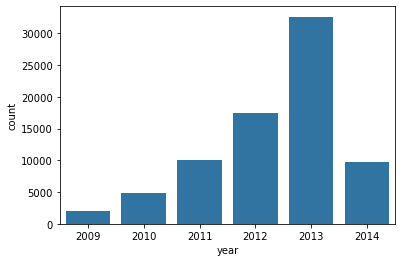

```python
base_color=sb.color_palette()[0]
sb.countplot(data=df,x='year',color=base_color);
```

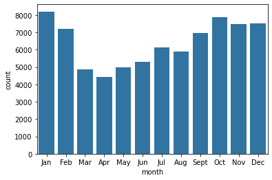

```python
order = ['Jan','Feb','Mar','Apr','May','Jun','Jul','Aug','Sept','Oct','Nov','Dec']
sb.countplot(data=df,x='month',color=base_color,order=order);
```

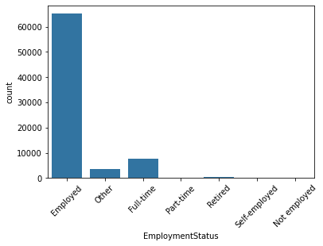

```python
sb.countplot(data=df,x='EmploymentStatus',color=base_color)
plt.xticks(rotation=45);
```

> Most of the borrowers are employed .

```
''
```

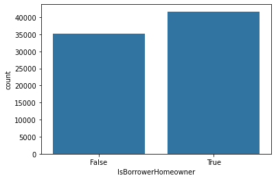

```python
sb.countplot(data=df,x='IsBorrowerHomeowner',color=base_color);
;
```

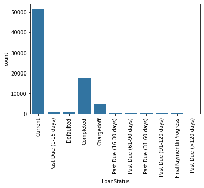

```python
sb.countplot(data=df,x='LoanStatus',color=base_color)
plt.xticks(rotation=90);
```

> The completed loans are greater than charged off & defaulted loans.

```python
df['BorrowerAPR'].describe()
```

```
count    76768.000000
mean         0.223978
std          0.079291
min          0.045830
25%          0.162590
50%          0.215660
75%          0.287800
max          0.423950
Name: BorrowerAPR, dtype: float64
```

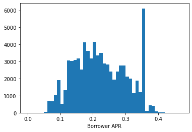

```python
bins = np.arange(0, df.BorrowerAPR.max()+0.05, 0.01)
plt.hist(data = df, x = 'BorrowerAPR', bins = bins);
plt.xlabel('Borrower APR');
```

> The borrower APR ranges from 0.05 to 0.4, The maximum borrower APR counts is at 0.35. The graph for the borrower APR is normally distributed except for alarge peak between 0.3,0.4.

```python
df['LoanOriginalAmount'].describe()
```

```
count    76768.000000
mean      9248.961416
std       6389.782292
min       1000.000000
25%       4000.000000
50%       8000.000000
75%      14000.000000
max      35000.000000
Name: LoanOriginalAmount, dtype: float64
```

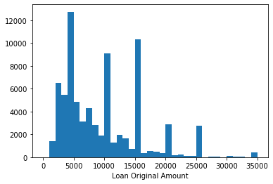

```python
bins = np.arange(0, df.LoanOriginalAmount.max()+1000, 1000)
plt.hist(data = df, x = 'LoanOriginalAmount', bins = bins);
plt.xlabel('Loan Original Amount');
```

> There is a very large peaks at 5000,10000,15000

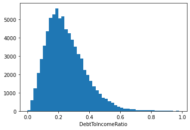

```python
# distribution of DebtToIncomeRatio
bins = np.arange(0,1, 0.02)
plt.hist(data = df, x = 'DebtToIncomeRatio', bins = bins);
plt.xlabel('DebtToIncomeRatio');
```

> The distribution has a peak around 0.2 which seems good .

> Make sure that, after every plot or related series of plots, that you include a Markdown cell with comments about what you observed, and what you plan on investigating next.

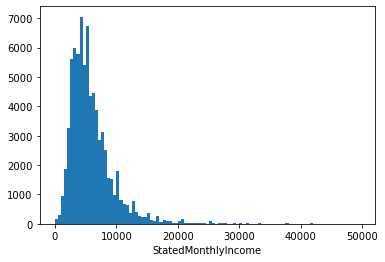

```python
# Distribution of stated monthly income
bins = np.arange(0, 50000, 500)
plt.hist(data = df, x = 'StatedMonthlyIncome', bins=bins);
plt.xlabel('StatedMonthlyIncome');
```

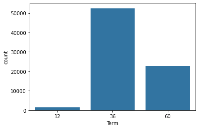

```python
sb.countplot(data = df, x = 'Term', color = base_color);
```

> We can see that 36 months term has the highest number of counts.

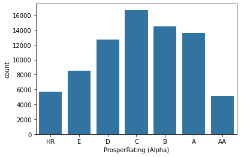

```python
order = ['HR','E','D','C','B','A','AA']
sb.countplot(data = df, x = 'ProsperRating (Alpha)', color = base_color,order=order);
```

> The graph of prosperRating is shown as a normal distribution, C has the largest no of counts.

### Discuss the distribution(s) of your variable(s) of interest. Were there any unusual points? Did you need to perform any transformations?

> The Loan status is a categorical variable which has 11 variables. I think no need of transformatioms.

### Of the features you investigated, were there any unusual distributions? Did you perform any operations on the data to tidy, adjust, or change the form of the data? If so, why did you do this?

> Stated monthly income & Debt to income ratio are highly right screwed.But I think no need of transformations.

## Bivariate Exploration

> In this section, investigate relationships between pairs of variables in your data. Make sure the variables that you cover here have been introduced in some fashion in the previous section (univariate exploration).

#### Plotting the relations between numerical variables.

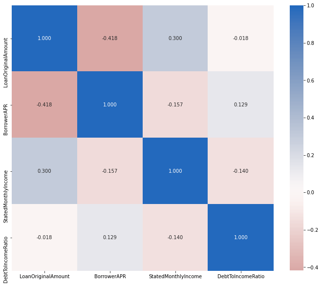

```python
num_vars = ['LoanOriginalAmount', 'BorrowerAPR','StatedMonthlyIncome','DebtToIncomeRatio']
plt.figure(figsize = [12, 10])
sb.heatmap(df[num_vars].corr(), annot = True, fmt = '.3f',
           cmap = 'vlag_r', center = 0);
```

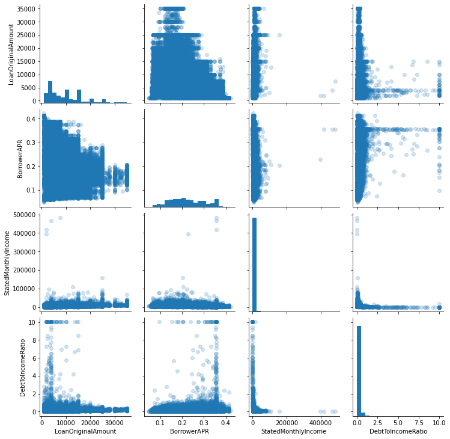

```python
g = sb.PairGrid(data = df, vars = num_vars)
g = g.map_diag(plt.hist, bins=20)
g.map_offdiag(plt.scatter, alpha=0.2);
```

> There is a negative correlation between loan original amount and borrower APR wich equals 0.42 , positive correlation between loan original amount and stated monthly income.

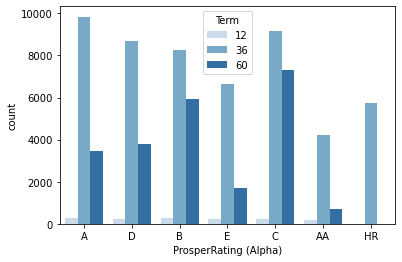

```python
sb.countplot(data = df, x = 'ProsperRating (Alpha)', hue = 'Term', palette = 'Blues');
```

> There are more 60 month loans on B and C ratings. There is only 36 months loans for HR rating borrowers.

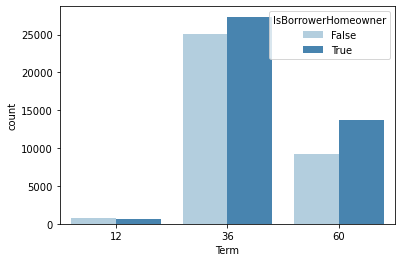

```python
sb.countplot(data = df, x = 'Term', hue = 'IsBorrowerHomeowner', palette = 'Blues');
```

> This graph doesn't give us any insights.

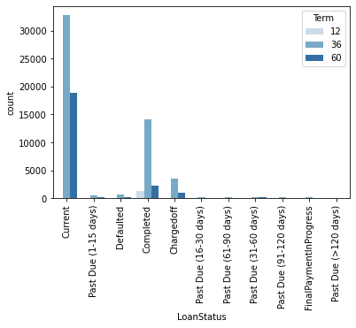

```python
sb.countplot(data = df, x = 'LoanStatus', hue = 'Term', palette = 'Blues')
plt.xticks(rotation=90);
```

> The most of 12 months term are completed.

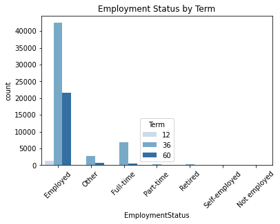

```python
sb.countplot(data = df, x = 'EmploymentStatus', hue = 'Term', palette = 'Blues')
plt.xticks(rotation=45);
plt.title('Employment Status by Term');
```

> There is only 12 loan month in employed.

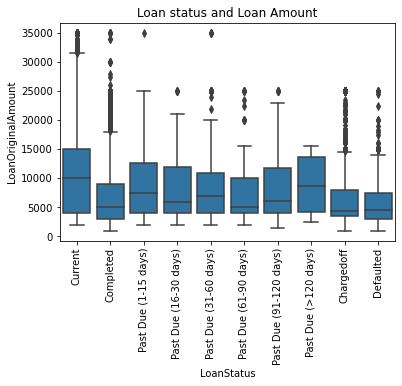

```python
order = ['Current','Completed','Past Due (1-15 days)','Past Due (16-30 days)','Past Due (31-60 days)','Past Due (61-90 days)','Past Due (91-120 days)','Past Due (>120 days)','Chargedoff','Defaulted']
sb.boxplot(data=df, x='LoanStatus', y='LoanOriginalAmount', color=base_color,order=order)
plt.xticks(rotation=90);
plt.title('Loan status and Loan Amount');
```